# Classify CCLE Cancer Cell Lines to Epithelial and Mesenchymal Using Known Gene Signatures

Scott Campit

*CAUTION: this code block ensures that your local R environment is cleared of any working variables.*

```r
rm(list=ls())
```

## Summary

This notebook classifies CCLE cancer cell lines as Epithelial or Mesenchymal based on known EMT signatures from MSigDB and EMTome.

```r
library(tidyverse)
```

```r
library(readxl)
library(ggplot2)
library(reshape)
library(yardstick)
```

## 1. Load EMT signatures

There were 3 MSigDB curated up and down EMT signatures we were able to obtain. These EMT signatures were obtained from hepatocytes (GOTZMANN), mammary (JECHLINGER), and breast (SARRIO) cancer cells.

**NOTE:** The EMTome used in this analysis is A549-specific and provides a gene list, but does not tell us anything about directionality of regulation. Therefore, we used this data set as a filter.

**TO DOWNLOAD THE DATASET:** The dataset for this analysis can be found in this Zenodo repository. The final directory path should be assigned to the `path` variable in the code block below. Throughout the notebook, we’ll assume that the data is two directories up in the parent directory.

### A. Load upregulated EMT genes

These upregulated gene lists were obtained from MSigDB.

```r
#path = "../../data/"
path = "C:/Users/Scott/Desktop/data/"
gotzmann_up = read.table(paste(path, 'GOTZMANN_EPITHELIAL_TO_MESENCHYMAL_TRANSITION_UP.txt', sep=''),
                         skip = 2,
                         header = FALSE,
                         sep ='\n')

jechlinger_up = read.table(paste(path, 'JECHLINGER_EPITHELIAL_TO_MESENCHYMAL_TRANSITION_UP.txt', sep=''),
                         skip = 2,
                         header = FALSE,
                         sep ='\n')

sarrio_up = read.table(paste(path, 'SARRIO_EPITHELIAL_MESENCHYMAL_TRANSITION_UP.txt', sep=''),
                         skip = 2,
                         header = FALSE,
                         sep ='\n')
```

### B. Load downregulated EMT genes

These downregulated gene lists were obtained from MSigDB.

```r
gotzmann_dn = read.table(paste(path, 'GOTZMANN_EPITHELIAL_TO_MESENCHYMAL_TRANSITION_DN.txt', sep=''),
                         skip = 2,
                         header = FALSE,
                         sep ='\n')

jechlinger_dn = read.table(paste(path, 'JECHLINGER_EPITHELIAL_TO_MESENCHYMAL_TRANSITION_DN.txt', sep=''),
                         skip = 2,
                         header = FALSE,
                         sep ='\n')

sarrio_dn = read.table(paste(path, 'SARRIO_EPITHELIAL_MESENCHYMAL_TRANSITION_DN.txt', sep=''),
                         skip = 2,
                         header = FALSE,
                         sep ='\n')
```

### C. Load EMT Signature data (PMID30783512)

This gene list was curated from EMTome.

```r
Gordian = read.table(paste(path, 'PMID30783512.txt', sep=''),
                         skip = 2,
                         header = FALSE,
                         sep ='\n')
```

## 2. Get intersection between gene sets

To get a core set of EMT genes, we’ll take the intersection between gene lists

### A. Intersection Across Up List

```r
emt_up = intersect(gotzmann_up, jechlinger_up, sarrio_up, Gordian)
```

### B. Intersection Across Down List

```r
emt_dn = intersect(gotzmann_dn, jechlinger_dn, sarrio_dn, Gordian)
```

## 3. Load up the CCLE Transcriptomics dataset

This section determines up- and downregulated genes from CCLE cancer cell lines using the transcriptomics dataset, normalized to TPM values. To determine up- and downregulation, we’ll take the Z-score and two-sided p-values of the Z-scores. Up-regulation is defined as having a positive Z-score and a p-value < 0.05. Down-regulation is defined as having a negative Z-score and a p-value < 0.05.

Here is a description of the CCLE transcriptomics dataset from the original README:

```
### CCLE_expression.csv

Pipeline: Expression

RNAseq TPM gene expression data for just protein coding genes using RSEM. Log2 transformed, using a pseudo-count of 1.

- Rows: cell lines (Broad IDs)
- Columns: genes (HGNC symbol and Entrez ID)
```

### A. Load Transcriptomics Data

First, load the transcriptomics dataset.

```r
ccle_rnaseq_tpm = readxl::read_excel(paste(path, 'CCLE_expression.xlsx', sep=''),
                                     sheet="RSEM Symbol")
```

### B. Calculate Z-score and P-value

Next, we’ll calculate the Z-score (`z_tmp`) and the two-sided p-value of the Z-scores (`p_tmp`).

```r
ach_id = ccle_rnaseq_tpm[, 1]
tmp = ccle_rnaseq_tpm[, -1]

z_tmp = scale(tmp, center=TRUE, scale=TRUE)
p_tmp = 2*pnorm(abs(z_tmp), mean=0, sd=1, lower.tail=FALSE)
```

For QA, let’s visualize the Z-score distribution and see if the normality assumption holds.

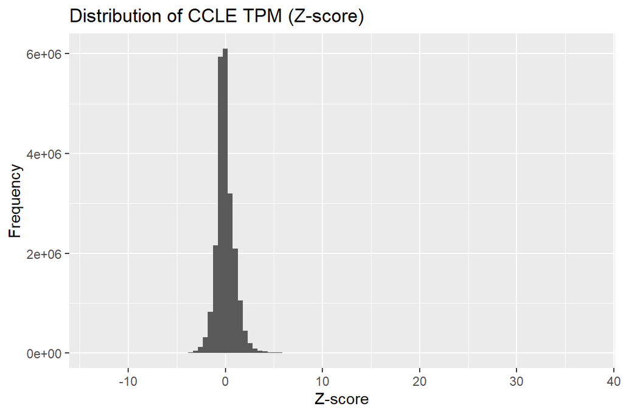

```r
ggplot(melt(z_tmp), aes(x=value)) +
  geom_histogram(bins=100) +
  xlab("Z-score") +
  ylab("Frequency") +
  ggtitle("Distribution of CCLE TPM (Z-score)")
```

Further, let’s see the distribution of P-values.

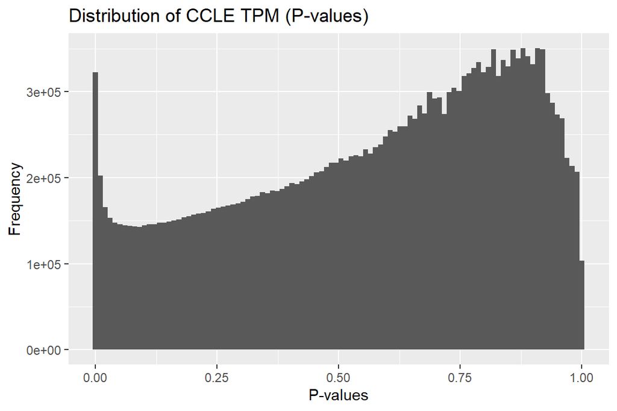

```r
ggplot(melt(p_tmp), aes(x=value)) +
  geom_histogram(bins=100) +
  xlab("P-values") +
  ylab("Frequency") +
  ggtitle("Distribution of CCLE TPM (P-values)")
```

### C. Extract Up- and Downregulated EMT Signatures for each cancer cell line. First, we’ll get the indicies of Z-scores that are positive / negative and where the corresponding p-value is < 0.05.

```r
z_up_idx = z_tmp > 0
z_dn_idx = z_tmp < 0
z_mask = p_tmp < 0.05
```

If we use both the directionality and the significance masks, we will obtain a very sparse list.

```r
z_up = z_tmp
z_up[!(z_up_idx & z_mask)] = NaN

z_dn = z_tmp
z_dn[!(z_dn_idx & z_mask)] = NaN
```

Therefore, for downstream analyses, I only used the up and down directionality.

```r
z_up = z_tmp
z_up[!(z_up_idx)] = NaN

z_dn = z_tmp
z_dn[!(z_dn_idx)] = NaN
```

Let’s convert to a data frame for both sets of EMT signatures.

```r
z_up = data.frame(z_up)
z_up = subset(z_up, select=as.matrix(emt_up))

z_dn = data.frame(z_dn)
z_dn = subset(z_dn, select=as.matrix(emt_dn))
```

## 4. CCLE Cancer Cell Line Classification.

We’ll classify cells whether or not they are E or M using the number of up and downregulated genes.

### A. Grab NSCLC Cell Lines and Map to EMT Signatures

First, get cell lines that are NSCLC specific.

```r
meta_data = read.table(paste(path, "sample_info.csv", sep=''),
                       sep=',',
                       fill=TRUE,
                       header=TRUE)
nsclc_meta = meta_data[meta_data$lineage_subtype=='NSCLC', ]
```

Now map the z_up and z_dn based on the meta data.

```r
match = intersect(ach_id$ACH_ID, nsclc_meta$DepMap_ID)
match_idx = which(ach_id$ACH_ID %in% nsclc_meta$DepMap_ID)
```

Now let’s get the intersecting data.

```r
nsclc_achid = ach_id[match_idx, ]
nsclc_meta = merge(nsclc_meta, nsclc_achid,
                   by.x="DepMap_ID", by.y="ACH_ID"
                  )

nsclc_zup = z_up[match_idx, ]
rownames(nsclc_zup) = as.matrix(nsclc_achid)

nsclc_zdn = z_dn[match_idx, ]
rownames(nsclc_zdn) = as.matrix(nsclc_achid)
```

We’ll now create a variable called `cmb` that combines the up and down EMT signatures from NSCLC cancer cell lines.

```r
cmb = cbind(nsclc_zup, nsclc_zdn)

cmb_idx = (cmb > 0 | cmb < 0)
cmb_idx[is.na(cmb_idx)] = 0
```

### B. Determine distribution of EMT Signature Differential Expresssion in NSCLC cell lines

Let’s get a sense of the number of EMT signatures captured. Recall that if the number of signatures high, that indicates those cell lines are leaning towards the mesenchymal state. Otherwise, if the number of EMT signatures differentially expressed is low, that means the cell line is closer towards the epithelial state.

Note that the total number of signatures is 14 (6 down, 8 up). We’ll draw a line at 7, which is the midpoint.

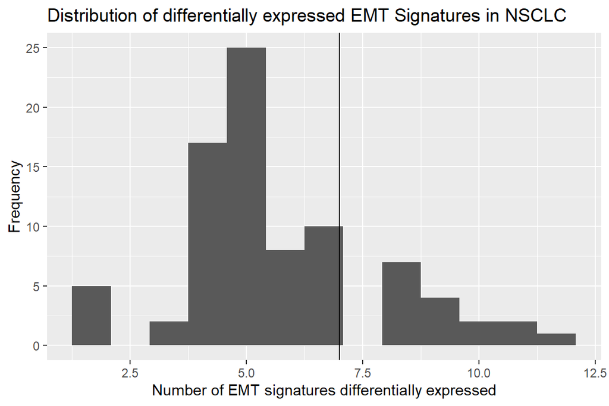

```r
tmp = data.frame(rowSums(cmb_idx, na.rm=TRUE))
colnames(tmp) = "value"

ggplot(tmp, aes(x=value)) +
  geom_histogram(bins=13) +
  xlab("Number of EMT signatures differentially expressed") +
  ylab("Frequency") +
  ggtitle("Distribution of differentially expressed EMT Signatures in NSCLC") +
  geom_vline(xintercept=7)
```

Many NSCLC cell lines don’t really have a ton of differential expression for EMT signatures, but there are many that have lower levels (less than 7 EMT signatures).

### C. Classify the NSCLC Cell Lines using quantile thresholds.

Let’s get the quantile thresholds for the number of significant EMT signatures.

```r
cmb$numSig = rowSums(!is.na(cmb))
quantile(cmb$numSig)
```

```
##   0%  25%  50%  75% 100%
##    2    4    5    7   12
```

Now we’ll subset data based on quantiles determined above.

```r
# By default, the cell state is set to "I"
cmb$State = "I"
cmb$State[cmb$numSig <= 4] = "E"
cmb$State[cmb$numSig >= 7] = "M"
```

### D. Label encode the EMT classes

Now let’s label encode the EMT classes.

```r
cmb$state_encoding = NA

# M = 1; E = 0
cmb$state_encoding[cmb$State == "E"] = 0
cmb$state_encoding[cmb$State == "I"] = 2
cmb$state_encoding[cmb$State == "M"] = 1

encoding = cmb[!is.na(cmb$state_encoding), ]
encoding = encoding[encoding$State != "I", ]
```

The CCLE cancer cell lines also have annotations for whether they were obtained from a primary cancer site (P), or were metastatic (M). We’ll compare how well the E/M classification corresponds to the P/M classification scheme.

```r
# Get primary and metastasis annotation
col2get = nsclc_meta[, c("DepMap_ID", "primary_or_metastasis")]
encoding = merge(encoding, col2get, by.x=0, by.y="DepMap_ID")

# M = 1; P = 0
encoding$pm_encoding = 0
encoding$pm_encoding[encoding$primary_or_metastasis == "Metastasis"] = 1
```

We’ll do some quick preprocessing and convert the columns into the factor datatype.

```r
encoding$state_encoding = as.factor(encoding$state_encoding)
encoding$pm_encoding = as.factor(encoding$pm_encoding)
```

## 5. Visualize the CCLE annotation (P/M) versus our EMT classification (E/M)

The code below create a confusion matrix given the two encoding schemes.

```r
cm = conf_mat(data=encoding,
              estimate=state_encoding, truth=pm_encoding)
cm
```

```
##           Truth
## Prediction  0  1
##          0 12 12
##          1 16 10
```

Now let’s visualize the confusion matrix. This panel will end up being Figure 6A in the manuscript.

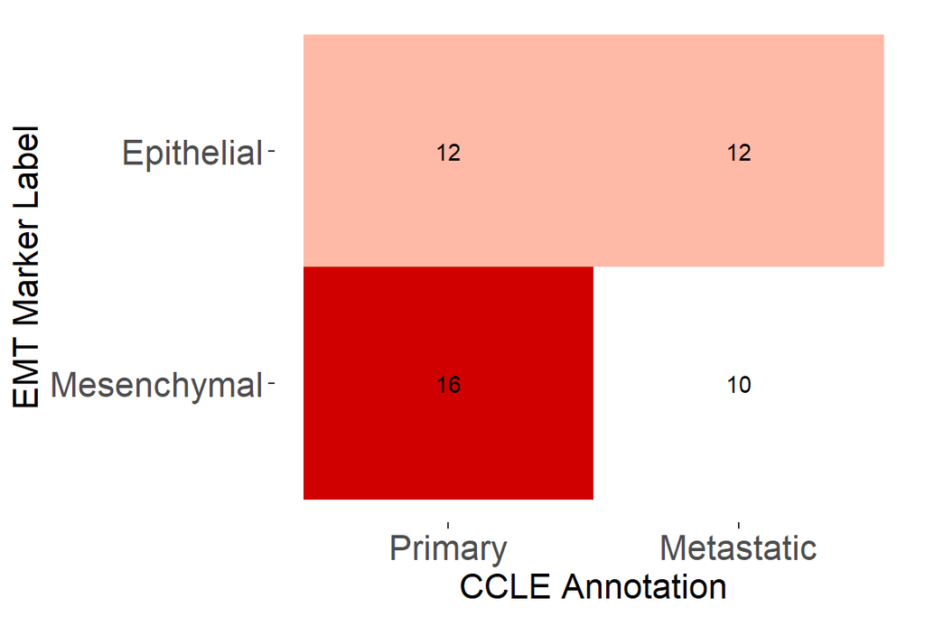

```r
autoplot(cm, type = "heatmap") +
  scale_x_discrete(breaks=c("0", "1"),
        labels=c("Primary", "Metastatic")) +
  scale_y_discrete(breaks=c("0", "1"),
        labels=c("Epithelial", "Mesenchymal")) +
  xlab("CCLE Annotation") +
  ylab("EMT Marker Label") +
  scale_fill_gradient(low="white", high="#D00000") +
  theme(plot.title = element_text(size=16),
        legend.text=element_text(size=16),
        axis.title.x=element_text(size=16),
        axis.title.y=element_text(size=16),
        axis.text.x=element_text(size=16),
        axis.text.y=element_text(size=16),
        legend.box="vertical",
        legend.margin=margin(),
        text=element_text(family="sans"))
```